# Project: Identify Customer Segments

In this project, you will apply unsupervised learning techniques to identify segments of the population that form the core customer base for a mail-order sales company in Germany. These segments can then be used to direct marketing campaigns towards audiences that will have the highest expected rate of returns. The data that you will use has been provided by our partners at Bertelsmann Arvato Analytics, and represents a real-life data science task.

This notebook will help you complete this task by providing a framework within which you will perform your analysis steps. In each step of the project, you will see some text describing the subtask that you will perform, followed by one or more code cells for you to complete your work. **Feel free to add additional code and markdown cells as you go along so that you can explore everything in precise chunks.** The code cells provided in the base template will outline only the major tasks, and will usually not be enough to cover all of the minor tasks that comprise it.

It should be noted that while there will be precise guidelines on how you should handle certain tasks in the project, there will also be places where an exact specification is not provided. **There will be times in the project where you will need to make and justify your own decisions on how to treat the data.** These are places where there may not be only one way to handle the data. In real-life tasks, there may be many valid ways to approach an analysis task. One of the most important things you can do is clearly document your approach so that other scientists can understand the decisions you've made.

At the end of most sections, there will be a Markdown cell labeled **Discussion**. In these cells, you will report your findings for the completed section, as well as document the decisions that you made in your approach to each subtask. **Your project will be evaluated not just on the code used to complete the tasks outlined, but also your communication about your observations and conclusions at each stage.**

```python
import pandas as pd
import numpy as np
from sklearn.decomposition import PCA
from sklearn.preprocessing import StandardScaler
from sklearn.ensemble import RandomForestClassifier
from sklearn.model_selection import train_test_split
from sklearn.metrics import confusion_matrix, accuracy_score

import matplotlib.image as mpimg
import matplotlib.pyplot as plt
import seaborn as sns

%matplotlib inline

'''
Import note: The classroom currently uses sklearn version 0.19.
If you need to use an imputer, it is available in sklearn.preprocessing.Imputer,
instead of sklearn.impute as in newer versions of sklearn.
'''
```

```
'\nImport note: The classroom currently uses sklearn version 0.19.\nIf you need to use an imputer, it is available in sklearn.preprocessing.Imputer,\ninstead of sklearn.impute as in newer versions of sklearn.\n'
```

### Step 0: Load the Data

There are four files associated with this project (not including this one):

Each row of the demographics files represents a single person, but also includes information outside of individuals, including information about their household, building, and neighborhood. You will use this information to cluster the general population into groups with similar demographic properties. Then, you will see how the people in the customers dataset fit into those created clusters. The hope here is that certain clusters are over-represented in the customers data, as compared to the general population; those over-represented clusters will be assumed to be part of the core userbase. This information can then be used for further applications, such as targeting for a marketing campaign.

To start off with, load in the demographics data for the general population into a pandas DataFrame, and do the same for the feature attributes summary. Note for all of the `.csv` data files in this project: they're semicolon (`;`) delimited, so you'll need an additional argument in your [`read_csv()`](https://pandas.pydata.org/pandas-docs/stable/generated/pandas.read_csv.html) call to read in the data properly. Also, considering the size of the main dataset, it may take some time for it to load completely.

Once the dataset is loaded, it's recommended that you take a little bit of time just browsing the general structure of the dataset and feature summary file. You'll be getting deep into the innards of the cleaning in the first major step of the project, so gaining some general familiarity can help you get your bearings.

```python
# Load in the general demographics data.
azdias = pd.read_csv("Udacity_AZDIAS_Subset.csv", delimiter=";")

# Load in the feature summary file.
feat_info = pd.read_csv("AZDIAS_Feature_Summary.csv", delimiter=";")
```

```python
# Check the structure of the data after it's loaded (e.g. print the number of
# rows and columns, print the first few rows).
print(f'Udacity AZDIAS Subset has {azdias.shape[0]} rows and {azdias.shape[1]} columns  \n')
print(f'AZDIAS Feature Summary has {feat_info.shape[0]} rows and {feat_info.shape[1]} columns')
```

```
Udacity AZDIAS Subset has 891221 rows and 85 columns

AZDIAS Feature Summary has 85 rows and 4 columns
```

```python
pd.set_option("display.max_rows", None)
azdias.sample(15).T
```

|  | 212332 | 836457 | 516431 | 246283 | 130023 | 376870 | 436881 | 437866 | 467099 | 472260 | 661846 | 286247 | 812061 | 190648 | 613792 |
| --- | --- | --- | --- | --- | --- | --- | --- | --- | --- | --- | --- | --- | --- | --- | --- |
| AGER_TYP | -1 | -1 | -1 | -1 | -1 | -1 | -1 | 1 | -1 | 3 | -1 | -1 | 2 | -1 | -1 |
| ALTERSKATEGORIE_GROB | 2 | 3 | 1 | 1 | 3 | 3 | 4 | 4 | 2 | 1 | 3 | 4 | 3 | 3 | 4 |
| ANREDE_KZ | 1 | 1 | 2 | 2 | 2 | 1 | 1 | 1 | 1 | 2 | 2 | 1 | 1 | 1 | 2 |
| CJT_GESAMTTYP | 4.0 | 3.0 | 5.0 | 6.0 | 3.0 | 4.0 | 5.0 | 5.0 | 4.0 | 2.0 | 6.0 | 1.0 | 4.0 | 6.0 | 2.0 |
| FINANZ_MINIMALIST | 1 | 3 | 1 | 1 | 2 | 3 | 4 | 5 | 1 | 2 | 3 | 5 | 3 | 3 | 3 |
| FINANZ_SPARER | 5 | 3 | 4 | 5 | 3 | 3 | 1 | 1 | 5 | 2 | 4 | 2 | 1 | 3 | 1 |
| FINANZ_VORSORGER | 2 | 3 | 2 | 3 | 4 | 4 | 5 | 5 | 3 | 5 | 3 | 4 | 5 | 3 | 5 |
| FINANZ_ANLEGER | 5 | 3 | 3 | 5 | 2 | 3 | 1 | 1 | 5 | 1 | 5 | 2 | 1 | 2 | 1 |
| FINANZ_UNAUFFAELLIGER | 5 | 1 | 5 | 4 | 2 | 1 | 2 | 2 | 4 | 1 | 5 | 2 | 1 | 1 | 2 |
| FINANZ_HAUSBAUER | 5 | 4 | 4 | 5 | 4 | 2 | 4 | 1 | 3 | 5 | 3 | 1 | 5 | 3 | 5 |
| FINANZTYP | 1 | 6 | 1 | 1 | 1 | 6 | 5 | 2 | 1 | 5 | 4 | 6 | 5 | 6 | 5 |
| GEBURTSJAHR | 2012 | 1973 | 1985 | 0 | 0 | 1968 | 0 | 1949 | 1991 | 1948 | 0 | 0 | 1950 | 0 | 0 |
| GFK_URLAUBERTYP | 10.0 | 12.0 | 8.0 | 3.0 | 4.0 | 11.0 | 4.0 | 5.0 | 12.0 | 11.0 | 5.0 | 3.0 | 3.0 | 11.0 | 10.0 |
| GREEN_AVANTGARDE | 0 | 1 | 0 | 0 | 0 | 0 | 0 | 1 | 0 | 0 | 0 | 1 | 0 | 0 | 1 |
| HEALTH_TYP | 3 | 3 | 3 | 3 | 3 | 3 | 2 | 2 | 3 | 3 | -1 | 1 | 3 | 3 | 2 |
| LP_LEBENSPHASE_FEIN | 33.0 | 4.0 | 29.0 | 1.0 | 5.0 | 31.0 | 6.0 | 40.0 | 3.0 | 31.0 | 0.0 | 13.0 | 6.0 | 5.0 | 8.0 |
| LP_LEBENSPHASE_GROB | 11.0 | 1.0 | 9.0 | 1.0 | 2.0 | 10.0 | 2.0 | 12.0 | 1.0 | 10.0 | 0.0 | 3.0 | 2.0 | 2.0 | 2.0 |
| LP_FAMILIE_FEIN | 10.0 | 1.0 | 10.0 | 1.0 | 1.0 | 10.0 | 1.0 | 11.0 | 1.0 | 10.0 | 0.0 | 1.0 | 1.0 | 1.0 | 1.0 |
| LP_FAMILIE_GROB | 5.0 | 1.0 | 5.0 | 1.0 | 1.0 | 5.0 | 1.0 | 5.0 | 1.0 | 5.0 | 0.0 | 1.0 | 1.0 | 1.0 | 1.0 |
| LP_STATUS_FEIN | 6.0 | 3.0 | 1.0 | 2.0 | 1.0 | 1.0 | 1.0 | 10.0 | 5.0 | 1.0 | 5.0 | 10.0 | 1.0 | 1.0 | 3.0 |
| LP_STATUS_GROB | 3.0 | 2.0 | 1.0 | 1.0 | 1.0 | 1.0 | 1.0 | 5.0 | 2.0 | 1.0 | 2.0 | 5.0 | 1.0 | 1.0 | 2.0 |
| NATIONALITAET_KZ | 1 | 1 | 1 | 1 | 1 | 1 | 1 | 1 | 1 | 1 | 0 | 1 | 1 | 1 | 1 |
| PRAEGENDE_JUGENDJAHRE | 14 | 13 | 14 | 14 | 8 | 10 | 0 | 6 | 14 | 5 | 0 | 9 | 5 | 8 | 6 |
| RETOURTYP_BK_S | 1.0 | 5.0 | 2.0 | 4.0 | 5.0 | 5.0 | 3.0 | 3.0 | 1.0 | 5.0 | 3.0 | 5.0 | 5.0 | 5.0 | 5.0 |
| SEMIO_SOZ | 7 | 6 | 5 | 2 | 1 | 6 | 6 | 6 | 7 | 5 | 2 | 3 | 6 | 3 | 5 |
| SEMIO_FAM | 7 | 6 | 4 | 4 | 2 | 5 | 6 | 5 | 7 | 4 | 6 | 2 | 2 | 6 | 1 |
| SEMIO_REL | 6 | 4 | 5 | 5 | 1 | 4 | 3 | 2 | 6 | 7 | 7 | 2 | 4 | 4 | 1 |
| SEMIO_MAT | 7 | 4 | 4 | 4 | 2 | 2 | 6 | 1 | 7 | 3 | 5 | 6 | 6 | 2 | 1 |
| SEMIO_VERT | 7 | 5 | 2 | 1 | 2 | 5 | 6 | 7 | 6 | 1 | 1 | 6 | 5 | 5 | 4 |
| SEMIO_LUST | 6 | 6 | 3 | 2 | 1 | 4 | 7 | 7 | 3 | 2 | 5 | 7 | 6 | 1 | 7 |

[output cut: 55 more lines]

```python
azdias.describe().T
```

|  | count | mean | std | min | 25% | 50% | 75% | max |
| --- | --- | --- | --- | --- | --- | --- | --- | --- |
| AGER_TYP | 891221.0 | -0.358435 | 1.198724 | -1.0 | -1.0 | -1.0 | -1.0 | 3.0 |
| ALTERSKATEGORIE_GROB | 891221.0 | 2.777398 | 1.068775 | 1.0 | 2.0 | 3.0 | 4.0 | 9.0 |
| ANREDE_KZ | 891221.0 | 1.522098 | 0.499512 | 1.0 | 1.0 | 2.0 | 2.0 | 2.0 |
| CJT_GESAMTTYP | 886367.0 | 3.632838 | 1.595021 | 1.0 | 2.0 | 4.0 | 5.0 | 6.0 |
| FINANZ_MINIMALIST | 891221.0 | 3.074528 | 1.321055 | 1.0 | 2.0 | 3.0 | 4.0 | 5.0 |
| FINANZ_SPARER | 891221.0 | 2.821039 | 1.464749 | 1.0 | 1.0 | 3.0 | 4.0 | 5.0 |
| FINANZ_VORSORGER | 891221.0 | 3.401106 | 1.322134 | 1.0 | 3.0 | 3.0 | 5.0 | 5.0 |
| FINANZ_ANLEGER | 891221.0 | 3.033328 | 1.529603 | 1.0 | 2.0 | 3.0 | 5.0 | 5.0 |
| FINANZ_UNAUFFAELLIGER | 891221.0 | 2.874167 | 1.486731 | 1.0 | 2.0 | 3.0 | 4.0 | 5.0 |
| FINANZ_HAUSBAUER | 891221.0 | 3.075121 | 1.353248 | 1.0 | 2.0 | 3.0 | 4.0 | 5.0 |
| FINANZTYP | 891221.0 | 3.790586 | 1.987876 | 1.0 | 2.0 | 4.0 | 6.0 | 6.0 |
| GEBURTSJAHR | 891221.0 | 1101.178533 | 976.583551 | 0.0 | 0.0 | 1943.0 | 1970.0 | 2017.0 |
| GFK_URLAUBERTYP | 886367.0 | 7.350304 | 3.525723 | 1.0 | 5.0 | 8.0 | 10.0 | 12.0 |
| GREEN_AVANTGARDE | 891221.0 | 0.196612 | 0.397437 | 0.0 | 0.0 | 0.0 | 0.0 | 1.0 |
| HEALTH_TYP | 891221.0 | 1.792102 | 1.269062 | -1.0 | 1.0 | 2.0 | 3.0 | 3.0 |
| LP_LEBENSPHASE_FEIN | 886367.0 | 14.622637 | 12.616883 | 0.0 | 4.0 | 11.0 | 27.0 | 40.0 |
| LP_LEBENSPHASE_GROB | 886367.0 | 4.453621 | 3.855639 | 0.0 | 1.0 | 3.0 | 8.0 | 12.0 |
| LP_FAMILIE_FEIN | 886367.0 | 3.599574 | 3.926486 | 0.0 | 1.0 | 1.0 | 8.0 | 11.0 |
| LP_FAMILIE_GROB | 886367.0 | 2.185966 | 1.756537 | 0.0 | 1.0 | 1.0 | 4.0 | 5.0 |
| LP_STATUS_FEIN | 886367.0 | 4.791151 | 3.425305 | 1.0 | 2.0 | 4.0 | 9.0 | 10.0 |
| LP_STATUS_GROB | 886367.0 | 2.432575 | 1.474315 | 1.0 | 1.0 | 2.0 | 4.0 | 5.0 |
| NATIONALITAET_KZ | 891221.0 | 1.026827 | 0.586634 | 0.0 | 1.0 | 1.0 | 1.0 | 3.0 |
| PRAEGENDE_JUGENDJAHRE | 891221.0 | 8.154346 | 4.844532 | 0.0 | 5.0 | 8.0 | 14.0 | 15.0 |
| RETOURTYP_BK_S | 886367.0 | 3.419630 | 1.417741 | 1.0 | 2.0 | 3.0 | 5.0 | 5.0 |
| SEMIO_SOZ | 891221.0 | 3.945860 | 1.946564 | 1.0 | 2.0 | 4.0 | 6.0 | 7.0 |
| SEMIO_FAM | 891221.0 | 4.272729 | 1.915885 | 1.0 | 3.0 | 4.0 | 6.0 | 7.0 |
| SEMIO_REL | 891221.0 | 4.240609 | 2.007373 | 1.0 | 3.0 | 4.0 | 6.0 | 7.0 |
| SEMIO_MAT | 891221.0 | 4.001597 | 1.857540 | 1.0 | 2.0 | 4.0 | 5.0 | 7.0 |
| SEMIO_VERT | 891221.0 | 4.023709 | 2.077746 | 1.0 | 2.0 | 4.0 | 6.0 | 7.0 |
| SEMIO_LUST | 891221.0 | 4.359086 | 2.022829 | 1.0 | 2.0 | 5.0 | 6.0 | 7.0 |

[output cut: 51 more lines]

```python
azdias.info()
```

```
<class 'pandas.core.frame.DataFrame'>
RangeIndex: 891221 entries, 0 to 891220
Data columns (total 85 columns):
 #   Column                 Non-Null Count   Dtype
---  ------                 --------------   -----
 0   AGER_TYP               891221 non-null  int64
 1   ALTERSKATEGORIE_GROB   891221 non-null  int64
 2   ANREDE_KZ              891221 non-null  int64
 3   CJT_GESAMTTYP          886367 non-null  float64
 4   FINANZ_MINIMALIST      891221 non-null  int64
 5   FINANZ_SPARER          891221 non-null  int64
 6   FINANZ_VORSORGER       891221 non-null  int64
 7   FINANZ_ANLEGER         891221 non-null  int64
 8   FINANZ_UNAUFFAELLIGER  891221 non-null  int64
 9   FINANZ_HAUSBAUER       891221 non-null  int64
```

[output cut: 77 more lines]

```python
feat_info.head(15)
```

|  | attribute | information_level | type | missing_or_unknown |
| --- | --- | --- | --- | --- |
| 0 | AGER_TYP | person | categorical | [-1,0] |
| 1 | ALTERSKATEGORIE_GROB | person | ordinal | [-1,0,9] |
| 2 | ANREDE_KZ | person | categorical | [-1,0] |
| 3 | CJT_GESAMTTYP | person | categorical | [0] |
| 4 | FINANZ_MINIMALIST | person | ordinal | [-1] |
| 5 | FINANZ_SPARER | person | ordinal | [-1] |
| 6 | FINANZ_VORSORGER | person | ordinal | [-1] |
| 7 | FINANZ_ANLEGER | person | ordinal | [-1] |
| 8 | FINANZ_UNAUFFAELLIGER | person | ordinal | [-1] |
| 9 | FINANZ_HAUSBAUER | person | ordinal | [-1] |
| 10 | FINANZTYP | person | categorical | [-1] |
| 11 | GEBURTSJAHR | person | numeric | [0] |
| 12 | GFK_URLAUBERTYP | person | categorical | [] |
| 13 | GREEN_AVANTGARDE | person | categorical | [] |
| 14 | HEALTH_TYP | person | ordinal | [-1,0] |

```python
feat_info.info()
```

```
<class 'pandas.core.frame.DataFrame'>
RangeIndex: 85 entries, 0 to 84
Data columns (total 4 columns):
 #   Column              Non-Null Count  Dtype
---  ------              --------------  -----
 0   attribute           85 non-null     object
 1   information_level   85 non-null     object
 2   type                85 non-null     object
 3   missing_or_unknown  85 non-null     object
dtypes: object(4)
memory usage: 2.8+ KB
```

> **Tip**: Add additional cells to keep everything in reasonably-sized chunks! Keyboard shortcut `esc --> a` (press escape to enter command mode, then press the 'A' key) adds a new cell before the active cell, and `esc --> b` adds a new cell after the active cell. If you need to convert an active cell to a markdown cell, use `esc --> m` and to convert to a code cell, use `esc --> y`.

## Step 1: Preprocessing

### Step 1.1: Assess Missing Data

The feature summary file contains a summary of properties for each demographics data column. You will use this file to help you make cleaning decisions during this stage of the project. First of all, you should assess the demographics data in terms of missing data. Pay attention to the following points as you perform your analysis, and take notes on what you observe. Make sure that you fill in the **Discussion** cell with your findings and decisions at the end of each step that has one!

#### Step 1.1.1: Convert Missing Value Codes to NaNs

The fourth column of the feature attributes summary (loaded in above as `feat_info`) documents the codes from the data dictionary that indicate missing or unknown data. While the file encodes this as a list (e.g. `[-1,0]`), this will get read in as a string object. You'll need to do a little bit of parsing to make use of it to identify and clean the data. Convert data that matches a 'missing' or 'unknown' value code into a numpy NaN value. You might want to see how much data takes on a 'missing' or 'unknown' code, and how much data is naturally missing, as a point of interest.

**As one more reminder, you are encouraged to add additional cells to break up your analysis into manageable chunks.**

```python
# First, I will have a look at the naturally missing values
azdias.isna().sum()
```

```
AGER_TYP                      0
ALTERSKATEGORIE_GROB          0
ANREDE_KZ                     0
CJT_GESAMTTYP              4854
FINANZ_MINIMALIST             0
FINANZ_SPARER                 0
FINANZ_VORSORGER              0
FINANZ_ANLEGER                0
FINANZ_UNAUFFAELLIGER         0
FINANZ_HAUSBAUER              0
FINANZTYP                     0
GEBURTSJAHR                   0
GFK_URLAUBERTYP            4854
GREEN_AVANTGARDE              0
HEALTH_TYP                    0
LP_LEBENSPHASE_FEIN        4854
LP_LEBENSPHASE_GROB        4854
LP_FAMILIE_FEIN            4854
LP_FAMILIE_GROB            4854
LP_STATUS_FEIN             4854
LP_STATUS_GROB             4854
NATIONALITAET_KZ              0
PRAEGENDE_JUGENDJAHRE         0
RETOURTYP_BK_S             4854
SEMIO_SOZ                     0
SEMIO_FAM                     0
SEMIO_REL                     0
SEMIO_MAT                     0
SEMIO_VERT                    0
SEMIO_LUST                    0
SEMIO_ERL                     0
SEMIO_KULT                    0
SEMIO_RAT                     0
SEMIO_KRIT                    0
SEMIO_DOM                     0
SEMIO_KAEM                    0
SEMIO_PFLICHT                 0
SEMIO_TRADV                   0
SHOPPER_TYP                   0
SOHO_KZ                   73499
```

[output cut: 31 more lines]

```
MOBI_REGIO               133324
ONLINE_AFFINITAET          4854
REGIOTYP                 121196
KBA13_ANZAHL_PKW         105800
PLZ8_ANTG1               116515
PLZ8_ANTG2               116515
PLZ8_ANTG3               116515
PLZ8_ANTG4               116515
PLZ8_BAUMAX              116515
PLZ8_HHZ                 116515
PLZ8_GBZ                 116515
ARBEIT                    97216
ORTSGR_KLS9               97216
RELAT_AB                  97216
dtype: int64
```

```python
print(f'Out of all the {azdias.shape[0]*azdias.shape[1]} values in the data frame, {azdias.isna().sum().sum()} ones \
or {((azdias.isna().sum().sum())/(azdias.shape[0]*azdias.shape[1]))*100:.2f}% are naturally missing')
```

```
Out of all the 75753785 values in the data frame, 4896838 ones or 6.46% are naturally missing
```

```python
# Identify missing or unknown data values and convert them to NaNs.
feat_info.missing_or_unknown.unique()
```

```
array(['[-1,0]', '[-1,0,9]', '[0]', '[-1]', '[]', '[-1,9]', '[-1,X]',
       '[XX]', '[-1,XX]'], dtype=object)
```

```python
azdias_cleaned = azdias.copy()
for column in azdias.columns:
    miss_unknown_array = feat_info[feat_info.attribute == column].missing_or_unknown.to_string().split()[1].strip('][').split(',')
    if miss_unknown_array[0] and 'XX' not in miss_unknown_array and 'X' not in miss_unknown_array:
        miss_unknown_array = np.array(list(map(int, miss_unknown_array)))
        azdias_cleaned = azdias_cleaned.replace({column:miss_unknown_array}, np.nan)
    elif miss_unknown_array[0]:
        azdias_cleaned = azdias_cleaned.replace({column:miss_unknown_array}, np.nan)
```

```python
print(f'After replacing the missing values, out of all the {azdias_cleaned.shape[0]*azdias_cleaned.shape[1]} values in the data frame, {azdias_cleaned.isna().sum().sum()} ones \
or {((azdias_cleaned.isna().sum().sum())/(azdias_cleaned.shape[0]*azdias_cleaned.shape[1]))*100:.2f} % are truelly missing')
```

```
After replacing the missing values, out of all the 75753785 values in the data frame, 8373929 ones or 11.05 % are truelly missing
```

#### Step 1.1.2: Assess Missing Data in Each Column

How much missing data is present in each column? There are a few columns that are outliers in terms of the proportion of values that are missing. You will want to use matplotlib's [`hist()`](https://matplotlib.org/api/_as_gen/matplotlib.pyplot.hist.html) function to visualize the distribution of missing value counts to find these columns. Identify and document these columns. While some of these columns might have justifications for keeping or re-encoding the data, for this project you should just remove them from the dataframe. (Feel free to make remarks about these outlier columns in the discussion, however!)

For the remaining features, are there any patterns in which columns have, or share, missing data?

```python
# Perform an assessment of how much missing data there is in each column of the dataset.
azdias_cleaned.isna().sum().sort_values()
```

```
ZABEOTYP                      0
SEMIO_TRADV                   0
SEMIO_PFLICHT                 0
SEMIO_KAEM                    0
SEMIO_DOM                     0
SEMIO_KRIT                    0
SEMIO_RAT                     0
SEMIO_KULT                    0
SEMIO_ERL                     0
SEMIO_LUST                    0
SEMIO_VERT                    0
SEMIO_MAT                     0
SEMIO_REL                     0
SEMIO_SOZ                     0
SEMIO_FAM                     0
FINANZ_VORSORGER              0
ANREDE_KZ                     0
FINANZ_MINIMALIST             0
FINANZ_SPARER                 0
FINANZ_ANLEGER                0
FINANZ_UNAUFFAELLIGER         0
FINANZ_HAUSBAUER              0
GREEN_AVANTGARDE              0
FINANZTYP                     0
ALTERSKATEGORIE_GROB       2881
GFK_URLAUBERTYP            4854
LP_STATUS_GROB             4854
LP_STATUS_FEIN             4854
ONLINE_AFFINITAET          4854
RETOURTYP_BK_S             4854
CJT_GESAMTTYP              4854
HH_EINKOMMEN_SCORE        18348
WOHNDAUER_2008            73499
ANZ_TITEL                 73499
SOHO_KZ                   73499
ANZ_PERSONEN              73499
KONSUMNAEHE               73969
LP_FAMILIE_GROB           77792
LP_FAMILIE_FEIN           77792
OST_WEST_KZ               93148
```

[output cut: 31 more lines]

```
KBA05_ANTG2              133324
KBA05_ANTG1              133324
MOBI_REGIO               133324
KBA05_GBZ                133324
KBA05_ANTG4              133324
W_KEIT_KIND_HH           147988
KKK                      158064
REGIOTYP                 158064
ALTER_HH                 310267
GEBURTSJAHR              392318
KBA05_BAUMAX             476524
KK_KUNDENTYP             584612
AGER_TYP                 685843
TITEL_KZ                 889061
dtype: int64
```

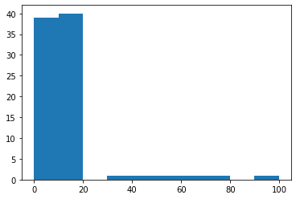

```python
# Investigate patterns in the amount of missing data in each column.
missing_percent = azdias_cleaned.isna().sum()/azdias_cleaned.shape[0]*100
plt.hist(missing_percent);
```

```python
# Remove the outlier columns from the dataset. (You'll perform other data
# engineering tasks such as re-encoding and imputation later.)

# We saw that most of the columns have missing percent lower than 20%.
#So we can say that if a column has a missing percent over 20%, it is an outlier and we drop it.

for column in azdias_cleaned.columns[azdias_cleaned.isna().sum()/azdias_cleaned.shape[0]*100 > 20]:
    print(f"Column {column} has NaNs percentage of {azdias_cleaned[column].isna().sum()/azdias_cleaned.shape[0]*100:.2f}%")
    azdias_cleaned.drop(column, axis =1, inplace = True)

print('\n These columns seemed to be outliers and are removed from the dataset')
```

```
Column AGER_TYP has NaNs percentage of 76.96%
Column GEBURTSJAHR has NaNs percentage of 44.02%
Column TITEL_KZ has NaNs percentage of 99.76%
Column ALTER_HH has NaNs percentage of 34.81%
Column KK_KUNDENTYP has NaNs percentage of 65.60%
Column KBA05_BAUMAX has NaNs percentage of 53.47%

 These columns seemed to be outliers and are removed from the dataset
```

```python
azdias_cleaned.isna().sum().unique()
```

```
array([  2881,      0,   4854, 111196,  97632,  94572,  77792, 108315,
       108164,  73499,  18348, 147988,  99611,  97008,  93148,  73969,
        99352, 133324,  93740,  93155, 158064, 105800, 116515,  97375,
        97274], dtype=int64)
```

```python
azdias_cleaned.isna().sum().sort_values()
```

```
ZABEOTYP                      0
SEMIO_REL                     0
SEMIO_MAT                     0
SEMIO_VERT                    0
SEMIO_LUST                    0
SEMIO_ERL                     0
SEMIO_KULT                    0
SEMIO_RAT                     0
SEMIO_KRIT                    0
SEMIO_DOM                     0
SEMIO_KAEM                    0
GREEN_AVANTGARDE              0
SEMIO_PFLICHT                 0
FINANZTYP                     0
FINANZ_HAUSBAUER              0
FINANZ_UNAUFFAELLIGER         0
FINANZ_ANLEGER                0
FINANZ_VORSORGER              0
FINANZ_SPARER                 0
FINANZ_MINIMALIST             0
SEMIO_TRADV                   0
ANREDE_KZ                     0
SEMIO_SOZ                     0
SEMIO_FAM                     0
ALTERSKATEGORIE_GROB       2881
LP_STATUS_GROB             4854
LP_STATUS_FEIN             4854
ONLINE_AFFINITAET          4854
RETOURTYP_BK_S             4854
GFK_URLAUBERTYP            4854
CJT_GESAMTTYP              4854
HH_EINKOMMEN_SCORE        18348
SOHO_KZ                   73499
WOHNDAUER_2008            73499
ANZ_TITEL                 73499
ANZ_PERSONEN              73499
KONSUMNAEHE               73969
LP_FAMILIE_GROB           77792
LP_FAMILIE_FEIN           77792
GEBAEUDETYP               93148
```

[output cut: 25 more lines]

```
PLZ8_BAUMAX              116515
PLZ8_ANTG4               116515
PLZ8_ANTG3               116515
PLZ8_ANTG1               116515
PLZ8_ANTG2               116515
KBA05_GBZ                133324
KBA05_ANTG1              133324
KBA05_ANTG2              133324
KBA05_ANTG3              133324
KBA05_ANTG4              133324
MOBI_REGIO               133324
W_KEIT_KIND_HH           147988
REGIOTYP                 158064
KKK                      158064
dtype: int64
```

```python
(azdias_cleaned.isna().sum()==0).sum()
```

```
24
```

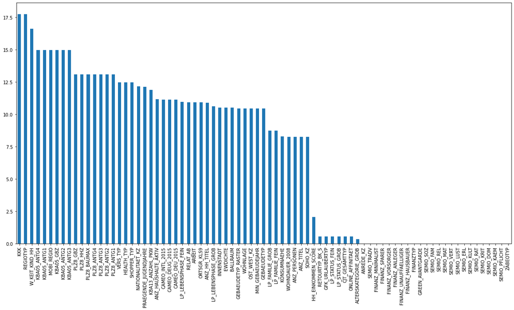

```python
(azdias_cleaned.isna().sum().sort_values(ascending=False)/azdias_cleaned.shape[0]*100).plot.bar(figsize=(20, 10));
```

#### Discussion 1.1.2: Assess Missing Data in Each Column

| Column | Defenition | Percent of NaNs |
| --- | --- | --- |
| AGER_TYP | Best-ager typology | 76.96% |
| GEBURTSJAHR | Year of birth | 44.02% |
| TITEL_KZ | Academic title flag | 99.76% |
| ALTER_HH | Birthdate of head of household | 34.81% |
| KK_KUNDENTYP | Consumer pattern over past 12 months | 65.60% |
| KBA05_BAUMAX | Most common building type within the microcell | 53.47% |

1. Some of the columns have the same amount of missing data, as seen in the bar chart. For example, `LP_STATUS_GROB`, `LP_STATUS_FEIN`, `ONLINE_AFFINITAET`, `RETOURTYP_BK_S`, `GFK_URLAUBERTYP`, `CJT_GESAMTTYP` all have 4854 missing values.
1. 24 columns have no missing values.

#### Step 1.1.3: Assess Missing Data in Each Row

Now, you'll perform a similar assessment for the rows of the dataset. How much data is missing in each row? As with the columns, you should see some groups of points that have a very different numbers of missing values. Divide the data into two subsets: one for data points that are above some threshold for missing values, and a second subset for points below that threshold.

In order to know what to do with the outlier rows, we should see if the distribution of data values on columns that are not missing data (or are missing very little data) are similar or different between the two groups. Select at least five of these columns and compare the distribution of values.

- You can use seaborn's [`countplot()`](https://seaborn.pydata.org/generated/seaborn.countplot.html) function to create a bar chart of code frequencies and matplotlib's [`subplot()`](https://matplotlib.org/api/_as_gen/matplotlib.pyplot.subplot.html) function to put bar charts for the two subplots side by side.
- To reduce repeated code, you might want to write a function that can perform this comparison, taking as one of its arguments a column to be compared.

Depending on what you observe in your comparison, this will have implications on how you approach your conclusions later in the analysis. If the distributions of non-missing features look similar between the data with many missing values and the data with few or no missing values, then we could argue that simply dropping those points from the analysis won't present a major issue. On the other hand, if the data with many missing values looks very different from the data with few or no missing values, then we should make a note on those data as special. We'll revisit these data later on. **Either way, you should continue your analysis for now using just the subset of the data with few or no missing values.**

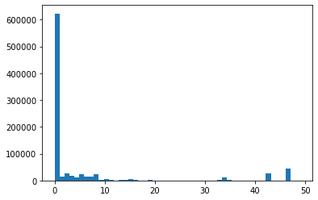

```python
# How much data is missing in each row of the dataset?
plt.hist(azdias_cleaned.isnull().sum(axis=1), bins=50);
```

```python
# Write code to divide the data into two subsets based on the number of missing
# values in each row.

pd.reset_option("display.max_rows")
azdias_cleaned['missing_values_row'] = azdias_cleaned.isnull().sum(axis=1)
azdias_cleaned.head(10)
```

|  | ALTERSKATEGORIE_GROB | ANREDE_KZ | CJT_GESAMTTYP | FINANZ_MINIMALIST | FINANZ_SPARER | FINANZ_VORSORGER | FINANZ_ANLEGER | FINANZ_UNAUFFAELLIGER | FINANZ_HAUSBAUER | FINANZTYP | ... | PLZ8_ANTG2 | PLZ8_ANTG3 | PLZ8_ANTG4 | PLZ8_BAUMAX | PLZ8_HHZ | PLZ8_GBZ | ARBEIT | ORTSGR_KLS9 | RELAT_AB | missing_values_row |
| --- | --- | --- | --- | --- | --- | --- | --- | --- | --- | --- | --- | --- | --- | --- | --- | --- | --- | --- | --- | --- | --- |
| 0 | 2.0 | 1 | 2.0 | 3 | 4 | 3 | 5 | 5 | 3 | 4 | ... | NaN | NaN | NaN | NaN | NaN | NaN | NaN | NaN | NaN | 43 |
| 1 | 1.0 | 2 | 5.0 | 1 | 5 | 2 | 5 | 4 | 5 | 1 | ... | 3.0 | 2.0 | 1.0 | 1.0 | 5.0 | 4.0 | 3.0 | 5.0 | 4.0 | 0 |
| 2 | 3.0 | 2 | 3.0 | 1 | 4 | 1 | 2 | 3 | 5 | 1 | ... | 3.0 | 1.0 | 0.0 | 1.0 | 4.0 | 4.0 | 3.0 | 5.0 | 2.0 | 0 |
| 3 | 4.0 | 2 | 2.0 | 4 | 2 | 5 | 2 | 1 | 2 | 6 | ... | 2.0 | 2.0 | 0.0 | 1.0 | 3.0 | 4.0 | 2.0 | 3.0 | 3.0 | 7 |
| 4 | 3.0 | 1 | 5.0 | 4 | 3 | 4 | 1 | 3 | 2 | 5 | ... | 4.0 | 2.0 | 1.0 | 2.0 | 3.0 | 3.0 | 4.0 | 6.0 | 5.0 | 0 |
| 5 | 1.0 | 2 | 2.0 | 3 | 1 | 5 | 2 | 2 | 5 | 2 | ... | 3.0 | 1.0 | 1.0 | 1.0 | 5.0 | 5.0 | 2.0 | 3.0 | 3.0 | 0 |
| 6 | 2.0 | 2 | 5.0 | 1 | 5 | 1 | 5 | 4 | 3 | 4 | ... | 3.0 | 1.0 | 0.0 | 1.0 | 5.0 | 5.0 | 4.0 | 6.0 | 3.0 | 0 |
| 7 | 1.0 | 1 | 3.0 | 3 | 3 | 4 | 1 | 3 | 2 | 5 | ... | 3.0 | 1.0 | 0.0 | 1.0 | 4.0 | 4.0 | 2.0 | 5.0 | 2.0 | 0 |
| 8 | 3.0 | 1 | 3.0 | 4 | 4 | 2 | 4 | 2 | 2 | 6 | ... | 3.0 | 2.0 | 1.0 | 1.0 | 3.0 | 3.0 | 2.0 | 4.0 | 3.0 | 0 |
| 9 | 3.0 | 2 | 4.0 | 2 | 4 | 2 | 3 | 5 | 4 | 1 | ... | 3.0 | 2.0 | 1.0 | 1.0 | 3.0 | 3.0 | 2.0 | 3.0 | 1.0 | 0 |

10 rows × 80 columns

```python
#In each row there are 79 values. I will split the dataset into two subsets with
#lower than 4 missing values (around 5% of 79) and more than that.

azdias_cleaned_noMissing = azdias_cleaned[azdias_cleaned['missing_values_row'] < 5]
azdias_cleaned_Missing = azdias_cleaned[azdias_cleaned['missing_values_row'] > 4]
print(f"The dataset has {azdias_cleaned.shape[0]} rows, out of which {azdias_cleaned_noMissing.shape[0]}\
 rows have less than 5 missing values and {azdias_cleaned_Missing.shape[0]} have more than 4 missing values")
```

```
The dataset has 891221 rows, out of which 697109 rows have less than 5 missing values and 194112 have more than 4 missing values
```

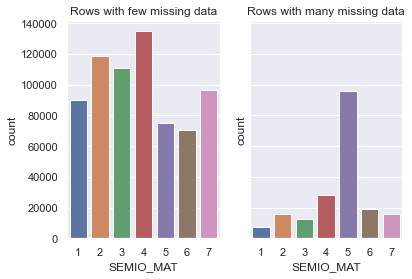

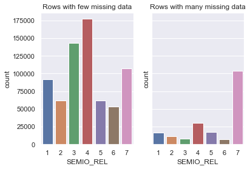

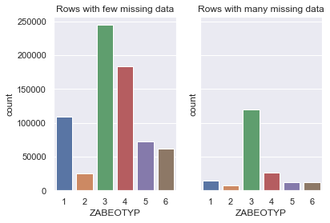

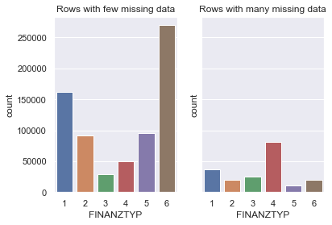

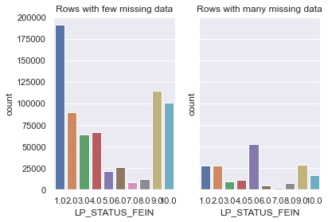

```python
# Compare the distribution of values for at least five columns where there are
# no or few missing values, between the two subsets.
def comparison_func(data1, data2, columnName):
    sns.set_theme(style="darkgrid")
    f, axs = plt.subplots(1,2, sharey=True);
    sns.countplot(ax=axs[0], x=column, data=data1)
    sns.countplot(ax=axs[1], x=column, data=data2)
    axs[0].set_title('Rows with few missing data');
    axs[1].set_title('Rows with many missing data');
    return

for column in ['SEMIO_MAT', 'SEMIO_REL', 'ZABEOTYP', 'FINANZTYP', 'LP_STATUS_FEIN']:
    comparison_func(azdias_cleaned_noMissing, azdias_cleaned_Missing, column)
```

#### Discussion 1.1.3: Assess Missing Data in Each Row

- As we see in the plots above, the distribution of data is not the same in the subsets with different percentage of missing data in rows. This could heavily affect the final result of clustering based on the chosen subset.

### Step 1.2: Select and Re-Encode Features

Checking for missing data isn't the only way in which you can prepare a dataset for analysis. Since the unsupervised learning techniques to be used will only work on data that is encoded numerically, you need to make a few encoding changes or additional assumptions to be able to make progress. In addition, while almost all of the values in the dataset are encoded using numbers, not all of them represent numeric values. Check the third column of the feature summary (`feat_info`) for a summary of types of measurement.

- For numeric and interval data, these features can be kept without changes.
- Most of the variables in the dataset are ordinal in nature. While ordinal values may technically be non-linear in spacing, make the simplifying assumption that the ordinal variables can be treated as being interval in nature (that is, kept without any changes).
- Special handling may be necessary for the remaining two variable types: categorical, and 'mixed'.

In the first two parts of this sub-step, you will perform an investigation of the categorical and mixed-type features and make a decision on each of them, whether you will keep, drop, or re-encode each. Then, in the last part, you will create a new data frame with only the selected and engineered columns.

Data wrangling is often the trickiest part of the data analysis process, and there's a lot of it to be done here. But stick with it: once you're done with this step, you'll be ready to get to the machine learning parts of the project!

```python
# How many features are there of each data type?
# first let us remove the rows from feat_info related to the dropped columns.
feat_info_cleaned = feat_info.copy()
for row in ['AGER_TYP', 'GEBURTSJAHR', 'TITEL_KZ', 'ALTER_HH', 'KK_KUNDENTYP', 'KBA05_BAUMAX']:
    feat_info_cleaned.drop(feat_info_cleaned[feat_info_cleaned['attribute']==row].index[0], axis = 0, inplace=True)

feat_info_cleaned.groupby('type').count()
```

| type | attribute | information_level | missing_or_unknown |
| --- | --- | --- | --- |
| categorical | 18 | 18 | 18 |
| mixed | 6 | 6 | 6 |
| numeric | 6 | 6 | 6 |
| ordinal | 49 | 49 | 49 |

#### Step 1.2.1: Re-Encode Categorical Features

For categorical data, you would ordinarily need to encode the levels as dummy variables. Depending on the number of categories, perform one of the following:

- For binary (two-level) categoricals that take numeric values, you can keep them without needing to do anything.
- There is one binary variable that takes on non-numeric values. For this one, you need to re-encode the values as numbers or create a dummy variable.
- For multi-level categoricals (three or more values), you can choose to encode the values using multiple dummy variables (e.g. via [OneHotEncoder](http://scikit-learn.org/stable/modules/generated/sklearn.preprocessing.OneHotEncoder.html)), or (to keep things straightforward) just drop them from the analysis. As always, document your choices in the Discussion section.

```python
# Assess categorical variables: which are binary, which are multi-level, and
# which one needs to be re-encoded?
for variable in feat_info_cleaned[feat_info_cleaned['type'] == 'categorical']['attribute']:
    print(f"Variable {variable} is categorical with {len(azdias_cleaned[variable].dropna().unique())} unique values.")
```

```
Variable ANREDE_KZ is categorical with 2 unique values.
Variable CJT_GESAMTTYP is categorical with 6 unique values.
Variable FINANZTYP is categorical with 6 unique values.
Variable GFK_URLAUBERTYP is categorical with 12 unique values.
Variable GREEN_AVANTGARDE is categorical with 2 unique values.
Variable LP_FAMILIE_FEIN is categorical with 11 unique values.
Variable LP_FAMILIE_GROB is categorical with 5 unique values.
Variable LP_STATUS_FEIN is categorical with 10 unique values.
Variable LP_STATUS_GROB is categorical with 5 unique values.
Variable NATIONALITAET_KZ is categorical with 3 unique values.
Variable SHOPPER_TYP is categorical with 4 unique values.
Variable SOHO_KZ is categorical with 2 unique values.
Variable VERS_TYP is categorical with 2 unique values.
Variable ZABEOTYP is categorical with 6 unique values.
Variable GEBAEUDETYP is categorical with 7 unique values.
Variable OST_WEST_KZ is categorical with 2 unique values.
Variable CAMEO_DEUG_2015 is categorical with 9 unique values.
Variable CAMEO_DEU_2015 is categorical with 44 unique values.
```

```python
# Re-encode categorical variable(s) to be kept in the analysis.
# I will drop the multi-level categoricals variables.

for variable in feat_info_cleaned[feat_info_cleaned['type'] == 'categorical']['attribute']:
    if len(azdias_cleaned[variable].dropna().unique()) > 2:
        azdias_cleaned.drop(variable, axis=1, inplace=True)
        print(f"Since {variable} is a multi-level categorical, it is droped.")
        feat_info_cleaned.drop(feat_info_cleaned[feat_info_cleaned['attribute']==variable].index[0], axis = 0, inplace=True)
```

```
Since CJT_GESAMTTYP is a multi-level categorical, it is droped.
Since FINANZTYP is a multi-level categorical, it is droped.
Since GFK_URLAUBERTYP is a multi-level categorical, it is droped.
Since LP_FAMILIE_FEIN is a multi-level categorical, it is droped.
Since LP_FAMILIE_GROB is a multi-level categorical, it is droped.
Since LP_STATUS_FEIN is a multi-level categorical, it is droped.
Since LP_STATUS_GROB is a multi-level categorical, it is droped.
Since NATIONALITAET_KZ is a multi-level categorical, it is droped.
Since SHOPPER_TYP is a multi-level categorical, it is droped.
Since ZABEOTYP is a multi-level categorical, it is droped.
Since GEBAEUDETYP is a multi-level categorical, it is droped.
Since CAMEO_DEUG_2015 is a multi-level categorical, it is droped.
Since CAMEO_DEU_2015 is a multi-level categorical, it is droped.
```

```python
for variable in feat_info_cleaned[feat_info_cleaned['type'] == 'categorical']['attribute']:
    print(azdias_cleaned[variable].value_counts())
```

```
2    465305
1    425916
Name: ANREDE_KZ, dtype: int64
0    715996
1    175225
Name: GREEN_AVANTGARDE, dtype: int64
0.0    810834
1.0      6888
Name: SOHO_KZ, dtype: int64
2.0    398722
1.0    381303
Name: VERS_TYP, dtype: int64
W    629528
O    168545
Name: OST_WEST_KZ, dtype: int64
```

```python
# We saw that OST_WEST_KZ is non-numeric values. I will assign number one to W and zero to O in this column.
# Also, two variables are binary but with 2 and 1 values. I will replace them with 1 and 0.
azdias_cleaned['ANREDE_KZ'].replace([2, 1], [1, 0], inplace=True)
azdias_cleaned['VERS_TYP'].replace([2.0, 1.0], [1, 0], inplace=True)
azdias_cleaned['OST_WEST_KZ'].replace(['W', 'O'], [1, 0], inplace=True)
```

#### Discussion 1.2.1: Re-Encode Categorical Features

- I dropped all the multi-level categorical values. They were 13 variables in total. Then, I changed all the binary ones so they will have only 1 and 0 values. Also, `OST_WEST_KZ` variable was non numerical, I assigned 1 to 'W's and 0 to 'O's. Also, to make the binary data consistent, I changed the 2 and 1 values in `ANREDE_KZ` and `VERS_TYP` to 1s and 0s.

#### Step 1.2.2: Engineer Mixed-Type Features

There are a handful of features that are marked as "mixed" in the feature summary that require special treatment in order to be included in the analysis. There are two in particular that deserve attention; the handling of the rest are up to your own choices:

- "PRAEGENDE_JUGENDJAHRE" combines information on three dimensions: generation by decade, movement (mainstream vs. avantgarde), and nation (east vs. west). While there aren't enough levels to disentangle east from west, you should create two new variables to capture the other two dimensions: an interval-type variable for decade, and a binary variable for movement.
- "CAMEO_INTL_2015" combines information on two axes: wealth and life stage. Break up the two-digit codes by their 'tens'-place and 'ones'-place digits into two new ordinal variables (which, for the purposes of this project, is equivalent to just treating them as their raw numeric values).
- If you decide to keep or engineer new features around the other mixed-type features, make sure you note your steps in the Discussion section.

Be sure to check `Data_Dictionary.md` for the details needed to finish these tasks.

```python
feat_info_cleaned[feat_info_cleaned['type'] == 'mixed']
```

|  | attribute | information_level | type | missing_or_unknown |
| --- | --- | --- | --- | --- |
| 15 | LP_LEBENSPHASE_FEIN | person | mixed | [0] |
| 16 | LP_LEBENSPHASE_GROB | person | mixed | [0] |
| 22 | PRAEGENDE_JUGENDJAHRE | person | mixed | [-1,0] |
| 56 | WOHNLAGE | building | mixed | [-1] |
| 59 | CAMEO_INTL_2015 | microcell_rr4 | mixed | [-1,XX] |
| 79 | PLZ8_BAUMAX | macrocell_plz8 | mixed | [-1,0] |

```python
# Investigate "PRAEGENDE_JUGENDJAHRE" and engineer two new variables.
azdias_cleaned['PRAEGENDE_JUGENDJAHRE'].value_counts()
```

```
14.0    188697
8.0     145988
5.0      86416
10.0     85808
3.0      55195
15.0     42547
11.0     35752
9.0      33570
6.0      25652
12.0     24446
1.0      21282
4.0      20451
2.0       7479
13.0      5764
7.0       4010
Name: PRAEGENDE_JUGENDJAHRE, dtype: int64
```

```python
azdias_cleaned['PRAEGENDE_JUGENDJAHRE_movement'] = azdias_cleaned['PRAEGENDE_JUGENDJAHRE']
azdias_cleaned['PRAEGENDE_JUGENDJAHRE_movement'].replace([1, 2, 3, 4, 5, 6, 7, 8, 9, 10, 11, 12, 13, 14, 15],\
                                   [1, 0, 1, 0, 1, 0, 0, 1, 0, 1, 0, 1, 0, 1, 0], inplace=True)
azdias_cleaned['PRAEGENDE_JUGENDJAHRE_decade'] = azdias_cleaned['PRAEGENDE_JUGENDJAHRE']
azdias_cleaned['PRAEGENDE_JUGENDJAHRE_decade'].replace([1, 2, 3, 4, 5, 6, 7, 8, 9, 10, 11, 12, 13, 14, 15],\
                                 [40, 40, 50, 50, 60, 60, 60, 70, 70, 80, 80, 80, 80, 90, 90], inplace=True)
```

```python
# Investigate "CAMEO_INTL_2015" and engineer two new variables.

azdias_cleaned['CAMEO_INTL_2015'].value_counts()
```

```
51    133694
41     92336
24     91158
14     62884
43     56672
54     45391
25     39628
22     33155
23     26750
13     26336
45     26132
55     23955
52     20542
31     19024
34     18524
15     16974
44     14820
12     13249
35     10356
32     10354
33      9935
Name: CAMEO_INTL_2015, dtype: int64
```

```python
azdias_cleaned['CAMEO_INTL_2015_wealth'] = (pd.to_numeric(azdias_cleaned['CAMEO_INTL_2015'])/10).round(0)

azdias_cleaned['CAMEO_INTL_2015_lifeStage'] = (pd.to_numeric(azdias_cleaned['CAMEO_INTL_2015'])%10).round(0)
```

```python
for variable in ['LP_LEBENSPHASE_FEIN', 'LP_LEBENSPHASE_GROB', 'WOHNLAGE','PLZ8_BAUMAX']:
    azdias_cleaned.drop(variable, axis=1, inplace=True)
    feat_info_cleaned.drop(feat_info_cleaned[feat_info_cleaned['attribute']==variable].index[0], axis = 0, inplace=True)
    print(f"Column {variable} is droped from both azdias_cleaned and feat_info_cleaned datasets.")
```

```
Column LP_LEBENSPHASE_FEIN is droped from both azdias_cleaned and feat_info_cleaned datasets.
Column LP_LEBENSPHASE_GROB is droped from both azdias_cleaned and feat_info_cleaned datasets.
Column WOHNLAGE is droped from both azdias_cleaned and feat_info_cleaned datasets.
Column PLZ8_BAUMAX is droped from both azdias_cleaned and feat_info_cleaned datasets.
```

#### Step 1.2.3: Complete Feature Selection

In order to finish this step up, you need to make sure that your data frame now only has the columns that you want to keep. To summarize, the dataframe should consist of the following:

- All numeric, interval, and ordinal type columns from the original dataset.
- Binary categorical features (all numerically-encoded).
- Engineered features from other multi-level categorical features and mixed features.

Make sure that for any new columns that you have engineered, that you've excluded the original columns from the final dataset. Otherwise, their values will interfere with the analysis later on the project. For example, you should not keep "PRAEGENDE_JUGENDJAHRE", since its values won't be useful for the algorithm: only the values derived from it in the engineered features you created should be retained. As a reminder, your data should only be from **the subset with few or no missing values**.

```python
# If there are other re-engineering tasks you need to perform, make sure you
# take care of them here. (Dealing with missing data will come in step 2.1.)

# I am dropping the following mixed columns because I made two variables out of them

for variable in ['PRAEGENDE_JUGENDJAHRE', 'CAMEO_INTL_2015']:
    azdias_cleaned.drop(variable, axis=1, inplace=True)
    print(f"Column {variable} is droped from both azdias_cleaned dataset.")
```

```
Column PRAEGENDE_JUGENDJAHRE is droped from both azdias_cleaned dataset.
Column CAMEO_INTL_2015 is droped from both azdias_cleaned dataset.
```

```python
# Do whatever you need to in order to ensure that the dataframe only contains
# the columns that should be passed to the algorithm functions.
```

### Step 1.3: Create a Cleaning Function

Even though you've finished cleaning up the general population demographics data, it's important to look ahead to the future and realize that you'll need to perform the same cleaning steps on the customer demographics data. In this substep, complete the function below to execute the main feature selection, encoding, and re-engineering steps you performed above. Then, when it comes to looking at the customer data in Step 3, you can just run this function on that DataFrame to get the trimmed dataset in a single step.

```python
def clean_data(df):
    """
    Perform feature trimming, re-encoding, and engineering for demographics
    data

    INPUT: Demographics DataFrame
    OUTPUT: Trimmed and cleaned demographics DataFrame
    """
    df_cleaned = df.copy()
    feat_info_cleaned = feat_info.copy()

    # Put in code here to execute all main cleaning steps:
    # convert missing value codes into NaNs, ...
    for column in df.columns:
        miss_unknown_array = feat_info[feat_info.attribute == column].missing_or_unknown.to_string().split()[1].strip('][').split(',')
        if miss_unknown_array[0] and 'XX' not in miss_unknown_array and 'X' not in miss_unknown_array:
            miss_unknown_array = np.array(list(map(int, miss_unknown_array)))
            df_cleaned = df_cleaned.replace({column:miss_unknown_array}, np.nan)
        elif miss_unknown_array[0]:
            df_cleaned = df_cleaned.replace({column:miss_unknown_array}, np.nan)

    # remove selected columns and rows, ...
    for column in df_cleaned.columns[df_cleaned.isna().sum()/df_cleaned.shape[0]*100 > 32]:
        print(f"Column {column} has NaNs percentage of {df_cleaned[column].isna().sum()/df_cleaned.shape[0]*100:.2f}%")
        df_cleaned.drop(column, axis =1, inplace = True)
        feat_info_cleaned.drop(feat_info_cleaned[feat_info_cleaned['attribute']==column].index[0], axis = 0, inplace=True)

    print('\nThese columns seemed to be outliers and are removed from the dataset \n')
    df_cleaned['missing_values_row'] = df_cleaned.isnull().sum(axis=1)

    # select, re-encode, and engineer column values.
    for variable in feat_info_cleaned[feat_info_cleaned['type'] == 'categorical']['attribute']:
        if len(df_cleaned[variable].dropna().unique()) > 2:
            df_cleaned.drop(variable, axis=1, inplace=True)
            print(f"Since {variable} is a multi-level categorical, it is droped.")
            feat_info_cleaned.drop(feat_info_cleaned[feat_info_cleaned['attribute']==variable].index[0], axis = 0, inplace=True)

    if 'ANREDE_KZ' in df_cleaned.columns:
        df_cleaned['ANREDE_KZ'].replace([2, 1], [1, 0], inplace=True)
    if 'VERS_TYP' in df_cleaned.columns:
        df_cleaned['VERS_TYP'].replace([2.0, 1.0], [1, 0], inplace=True)
    if 'OST_WEST_KZ' in df_cleaned.columns:
        df_cleaned['OST_WEST_KZ'].replace(['W', 'O'], [1, 0], inplace=True)

    if 'PRAEGENDE_JUGENDJAHRE' in df_cleaned.columns:
        df_cleaned['PRAEGENDE_JUGENDJAHRE_movement'] = df_cleaned['PRAEGENDE_JUGENDJAHRE']
        df_cleaned['PRAEGENDE_JUGENDJAHRE_movement'].replace([1, 2, 3, 4, 5, 6, 7, 8, 9, 10, 11, 12, 13, 14, 15],\
                                                             [1, 0, 1, 0, 1, 0, 0, 1, 0, 1, 0, 1, 0, 1, 0], inplace=True)
        df_cleaned['PRAEGENDE_JUGENDJAHRE_decade'] = df_cleaned['PRAEGENDE_JUGENDJAHRE']
        df_cleaned['PRAEGENDE_JUGENDJAHRE_decade'].replace([1, 2, 3, 4, 5, 6, 7, 8, 9, 10, 11, 12, 13, 14, 15],\
                                                           [40, 40, 50, 50, 60, 60, 60, 70, 70, 80, 80, 80, 80, 90, 90], inplace=True)

    if 'CAMEO_INTL_2015' in df_cleaned.columns:
        df_cleaned['CAMEO_INTL_2015_wealth'] = (pd.to_numeric(df_cleaned['CAMEO_INTL_2015'])/10).round(0)
        df_cleaned['CAMEO_INTL_2015_lifeStage'] = (pd.to_numeric(df_cleaned['CAMEO_INTL_2015'])%10).round(0)

    for variable in ['LP_LEBENSPHASE_FEIN', 'LP_LEBENSPHASE_GROB', 'WOHNLAGE','PLZ8_BAUMAX', 'PRAEGENDE_JUGENDJAHRE', 'CAMEO_INTL_2015']:
        if variable in df_cleaned.columns:
            df_cleaned.drop(variable, axis=1, inplace=True)
            feat_info_cleaned.drop(feat_info_cleaned[feat_info_cleaned['attribute']==variable].index[0], axis = 0, inplace=True)
            print(f"Column {variable} is droped from both  and datasets.")

    # Return the cleaned dataframe.
    return df_cleaned
```

```python
# I will test here to see if the function defined above, will produce the same dataset or not.
azdias = pd.read_csv("Udacity_AZDIAS_Subset.csv", delimiter=";")
test_df = clean_data(azdias)
```

```
Column AGER_TYP has NaNs percentage of 76.96%
Column GEBURTSJAHR has NaNs percentage of 44.02%
Column TITEL_KZ has NaNs percentage of 99.76%
Column ALTER_HH has NaNs percentage of 34.81%
Column KK_KUNDENTYP has NaNs percentage of 65.60%
Column KBA05_BAUMAX has NaNs percentage of 53.47%

These columns seemed to be outliers and are removed from the dataset

Since CJT_GESAMTTYP is a multi-level categorical, it is droped.
Since FINANZTYP is a multi-level categorical, it is droped.
Since GFK_URLAUBERTYP is a multi-level categorical, it is droped.
Since LP_FAMILIE_FEIN is a multi-level categorical, it is droped.
Since LP_FAMILIE_GROB is a multi-level categorical, it is droped.
Since LP_STATUS_FEIN is a multi-level categorical, it is droped.
Since LP_STATUS_GROB is a multi-level categorical, it is droped.
Since NATIONALITAET_KZ is a multi-level categorical, it is droped.
Since SHOPPER_TYP is a multi-level categorical, it is droped.
Since ZABEOTYP is a multi-level categorical, it is droped.
Since GEBAEUDETYP is a multi-level categorical, it is droped.
Since CAMEO_DEUG_2015 is a multi-level categorical, it is droped.
Since CAMEO_DEU_2015 is a multi-level categorical, it is droped.
Column LP_LEBENSPHASE_FEIN is droped from both  and datasets.
Column LP_LEBENSPHASE_GROB is droped from both  and datasets.
Column WOHNLAGE is droped from both  and datasets.
Column PLZ8_BAUMAX is droped from both  and datasets.
Column PRAEGENDE_JUGENDJAHRE is droped from both  and datasets.
Column CAMEO_INTL_2015 is droped from both  and datasets.
```

```python
test_df.equals(azdias_cleaned)
```

```
True
```

## Step 2: Feature Transformation

### Step 2.1: Apply Feature Scaling

Before we apply dimensionality reduction techniques to the data, we need to perform feature scaling so that the principal component vectors are not influenced by the natural differences in scale for features. Starting from this part of the project, you'll want to keep an eye on the [API reference page for sklearn](http://scikit-learn.org/stable/modules/classes.html) to help you navigate to all of the classes and functions that you'll need. In this substep, you'll need to check the following:

- sklearn requires that data not have missing values in order for its estimators to work properly. So, before applying the scaler to your data, make sure that you've cleaned the DataFrame of the remaining missing values. This can be as simple as just removing all data points with missing data, or applying an [Imputer](https://scikit-learn.org/0.16/modules/generated/sklearn.preprocessing.Imputer.html) to replace all missing values. You might also try a more complicated procedure where you temporarily remove missing values in order to compute the scaling parameters before re-introducing those missing values and applying imputation. Think about how much missing data you have and what possible effects each approach might have on your analysis, and justify your decision in the discussion section below.
- For the actual scaling function, a [StandardScaler](http://scikit-learn.org/stable/modules/generated/sklearn.preprocessing.StandardScaler.html) instance is suggested, scaling each feature to mean 0 and standard deviation 1.
- For these classes, you can make use of the `.fit_transform()` method to both fit a procedure to the data as well as apply the transformation to the data at the same time. Don't forget to keep the fit sklearn objects handy, since you'll be applying them to the customer demographics data towards the end of the project.

```python
# If you've not yet cleaned the dataset of all NaN values, then investigate and
# do that now.

from sklearn.impute import KNNImputer
from sklearn.impute import SimpleImputer

# First, I will make a subdataset with zero missing values in rows.
azdias_cleaned_0Missing = azdias_cleaned[azdias_cleaned.missing_values_row == 0].copy()
azdias_cleaned_0Missing.drop('missing_values_row', axis=1, inplace=True)
print(f"Percentage of the data where there are no missing values is \
{azdias_cleaned[azdias_cleaned.missing_values_row == 0].shape[0]/azdias_cleaned.shape[0]*100 :.2f}% \n")

#I will try to fill the NaN values and compare how both of these subsets work.
# azdias_cleaned_filledNaN = azdias_cleaned.copy()
# imputer = KNNImputer(n_neighbors=2) This is taking quite a lot of time, I will try that on the workshop with cuda if possible
# imputer.fit_transform(azdias_cleaned_filledNaN)

imputer = SimpleImputer(missing_values=np.nan, strategy='most_frequent')
azdias_cleaned_filledNaN = pd.DataFrame(imputer.fit_transform(azdias_cleaned))
azdias_cleaned_filledNaN.columns = azdias_cleaned.columns
azdias_cleaned_filledNaN.drop('missing_values_row', axis=1, inplace=True)

azdias_cleaned_filledNaN.isna().sum().sum()
```

```
Percentage of the data where there are no missing values is 69.93%
```

```
0
```

```python
# Apply feature scaling to the general population demographics data.

scaler1 = StandardScaler(copy=True, with_mean=True, with_std=True)
scaler2 = StandardScaler(copy=True, with_mean=True, with_std=True)

azdias_cleaned_0Missing_scaled = scaler1.fit_transform(azdias_cleaned_0Missing)
azdias_cleaned_0Missing_scaled = pd.DataFrame(azdias_cleaned_0Missing_scaled, columns=azdias_cleaned_0Missing.columns)

azdias_cleaned_filledNaN_scaled = scaler2.fit_transform(azdias_cleaned_filledNaN)
azdias_cleaned_filledNaN_scaled = pd.DataFrame(azdias_cleaned_filledNaN_scaled, columns=azdias_cleaned_filledNaN.columns)
```

### Discussion 2.1: Apply Feature Scaling

- I decided to make two data subsets. One which contains only the no missing values, and the other one with the filled NaNs by using SimpleImputer with `strategy = 'most_frequent'`. I will perform all the following analysis out of curiosity to see how these two datasets differ.

### Step 2.2: Perform Dimensionality Reduction

On your scaled data, you are now ready to apply dimensionality reduction techniques.

- Use sklearn's [PCA](http://scikit-learn.org/stable/modules/generated/sklearn.decomposition.PCA.html) class to apply principal component analysis on the data, thus finding the vectors of maximal variance in the data. To start, you should not set any parameters (so all components are computed) or set a number of components that is at least half the number of features (so there's enough features to see the general trend in variability).
- Check out the ratio of variance explained by each principal component as well as the cumulative variance explained. Try plotting the cumulative or sequential values using matplotlib's [`plot()`](https://matplotlib.org/api/_as_gen/matplotlib.pyplot.plot.html) function. Based on what you find, select a value for the number of transformed features you'll retain for the clustering part of the project.
- Once you've made a choice for the number of components to keep, make sure you re-fit a PCA instance to perform the decided-on transformation.

```python
# Apply PCA to the data.
pca1 = PCA()
pca2 = PCA()

pca1.fit(azdias_cleaned_0Missing_scaled);
pca2.fit(azdias_cleaned_filledNaN_scaled);
```

```python
# Investigate the variance accounted for by each principal component.
# I will use the scree_plot from the helper function of the udacity cource. I have modified it a bit.
def scree_plot(pca):
    '''
    Creates a scree plot associated with the principal components

    INPUT: pca - the result of instantian of PCA in scikit learn

    OUTPUT:
            None
    '''
    num_components=len(pca.explained_variance_ratio_)
    ind = np.arange(num_components)
    vals = pca.explained_variance_ratio_
    cumvals = np.cumsum(vals)

    fig, ax1 = plt.subplots(figsize=(20, 15))
    ax2 = ax1.twinx()

    ax1.bar(ind,pca.explained_variance_ratio_, color='blue');
    ax1.xaxis.set_tick_params(width=0)
    ax1.tick_params(axis="y", labelcolor='blue')
    ax1.set_ylabel("Variance Ratio", color='blue', fontsize=17);

    ax2.plot(ind, pca.explained_variance_ratio_.cumsum(), c='red');
    ax2.tick_params(axis="y", labelcolor='red');
    ax2.set_ylabel("Variance Explained (%)", color='red', fontsize=17);

    ax1.set_xlabel("Principal Component", fontsize=17)
    plt.title('Explained Variance Per Principal Component', fontsize=20)
```

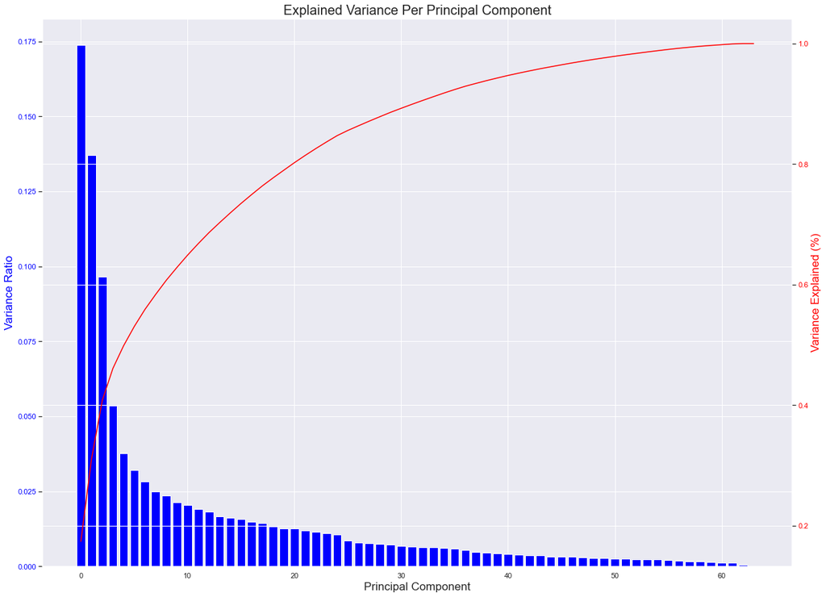

```python
scree_plot(pca1)
```

```python
cumvals = np.cumsum(pca1.explained_variance_ratio_*100)
for i in range(0, len(pca1.explained_variance_ratio_), 5):
    print(f"With {i+1} components, {cumvals[i]:.2f}% of total variance is achieved")
```

```
With 1 components, 17.38% of total variance is achieved
With 6 components, 53.04% of total variance is achieved
With 11 components, 64.90% of total variance is achieved
With 16 components, 73.47% of total variance is achieved
With 21 components, 80.24% of total variance is achieved
With 26 components, 85.58% of total variance is achieved
With 31 components, 89.26% of total variance is achieved
With 36 components, 92.37% of total variance is achieved
With 41 components, 94.71% of total variance is achieved
With 46 components, 96.47% of total variance is achieved
With 51 components, 97.89% of total variance is achieved
With 56 components, 99.03% of total variance is achieved
With 61 components, 99.82% of total variance is achieved
```

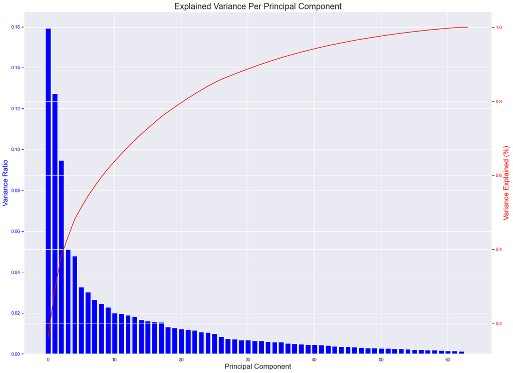

```python
scree_plot(pca2)
```

```python
cumvals = np.cumsum(pca2.explained_variance_ratio_*100)
for i in range(0, len(pca1.explained_variance_ratio_), 5):
    print(f"With {i+1} components, {cumvals[i]:.2f}% of total variance is achieved")
```

```
With 1 components, 15.94% of total variance is achieved
With 6 components, 51.31% of total variance is achieved
With 11 components, 63.74% of total variance is achieved
With 16 components, 72.69% of total variance is achieved
With 21 components, 79.60% of total variance is achieved
With 26 components, 85.05% of total variance is achieved
With 31 components, 88.72% of total variance is achieved
With 36 components, 91.77% of total variance is achieved
With 41 components, 94.18% of total variance is achieved
With 46 components, 96.11% of total variance is achieved
With 51 components, 97.62% of total variance is achieved
With 56 components, 98.83% of total variance is achieved
With 61 components, 99.73% of total variance is achieved
```

```python
# Re-apply PCA to the data while selecting for number of components to retain.
# looking at the percentages above, with 32 component we will reach around 90% of variance.
pca_32_1 = PCA(n_components=32)
pca_32_2 = PCA(n_components=32)

pca_32_1.fit(azdias_cleaned_0Missing_scaled)
pca_32_2.fit(azdias_cleaned_filledNaN_scaled)
```

```
PCA(n_components=32)
```

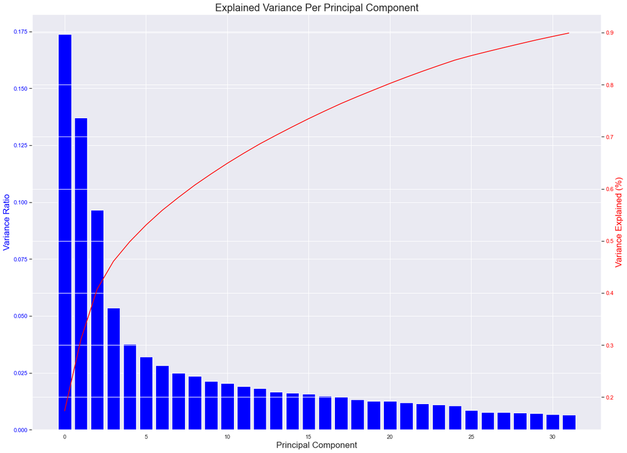

```python
scree_plot(pca_32_1)
```

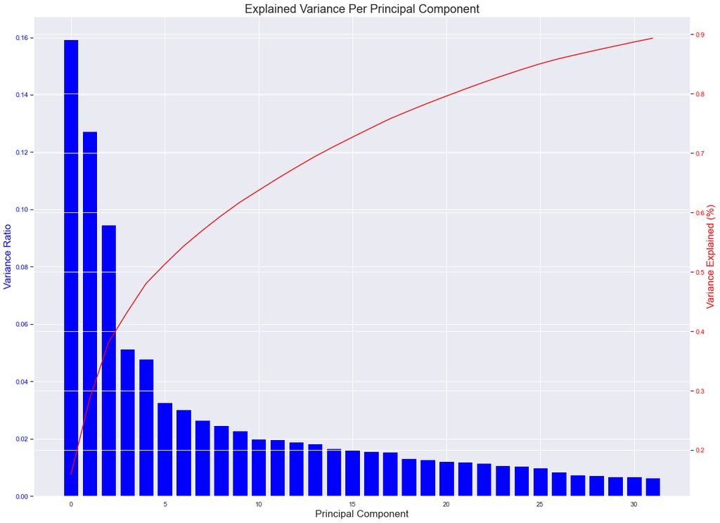

```python
scree_plot(pca_32_2)
```

### Discussion 2.2: Perform Dimensionality Reduction

- As we could see in the graphs of scree_plot function and also read from the cumsum values of the variance ratios, with **32** components we will have 90% of the variance. So, I will keep 32 PCA components.

### Step 2.3: Interpret Principal Components

Now that we have our transformed principal components, it's a nice idea to check out the weight of each variable on the first few components to see if they can be interpreted in some fashion.

As a reminder, each principal component is a unit vector that points in the direction of highest variance (after accounting for the variance captured by earlier principal components). The further a weight is from zero, the more the principal component is in the direction of the corresponding feature. If two features have large weights of the same sign (both positive or both negative), then increases in one tend expect to be associated with increases in the other. To contrast, features with different signs can be expected to show a negative correlation: increases in one variable should result in a decrease in the other.

- To investigate the features, you should map each weight to their corresponding feature name, then sort the features according to weight. The most interesting features for each principal component, then, will be those at the beginning and end of the sorted list. Use the data dictionary document to help you understand these most prominent features, their relationships, and what a positive or negative value on the principal component might indicate.
- You should investigate and interpret feature associations from the first three principal components in this substep. To help facilitate this, you should write a function that you can call at any time to print the sorted list of feature weights, for the *i*-th principal component. This might come in handy in the next step of the project, when you interpret the tendencies of the discovered clusters.

```python
# Map weights for the first principal component to corresponding feature names
# and then print the linked values, sorted by weight.
# HINT: Try defining a function here or in a new cell that you can reuse in the
# other cells.

# Also here I am using a function from helper functions of udacity
def pca_results(full_dataset, pca, component=None):

    if not component:
        # Dimension indexing
        dimensions = dimensions = ['Dimension {}'.format(i) for i in range(1,len(pca.components_)+1)]

        # PCA components
        components = pd.DataFrame(np.round(pca.components_, 4), columns = full_dataset.keys())
        components.index = dimensions

        # PCA explained variance
        ratios = pca.explained_variance_ratio_.reshape(len(pca.components_), 1)
        variance_ratios = pd.DataFrame(np.round(ratios, 4), columns = ['Explained Variance'])
        variance_ratios.index = dimensions

    else:
        # Dimension indexing
        dimensions = dimensions = ['Dimension {}'.format(component)]

        # PCA components
        components = pd.DataFrame(np.round(pca.components_[component-1], 4).reshape(1,64), columns = full_dataset.keys()).sort_values(by=0, axis=1, ascending=False)
        components.index = dimensions

        # PCA explained variance
        ratios = pca.explained_variance_ratio_[component-1]
        variance_ratios = pd.DataFrame(columns = ['Explained Variance'])
        variance_ratios.loc[0] = ratios
        variance_ratios.index = dimensions

    return pd.concat([variance_ratios, components], axis = 1)


def pca_top_features(full_dataset, pca, component, i):
    df = pca_results(full_dataset, pca, component)
    print(f"The Explained Variance for component {component} is {np.round(df.iloc[0][0]*100, 2)}% \
and the graph below shows the {2*i} features affecting this component the most")

    df2 = pd.concat([pd.DataFrame(df.iloc[0][1:i+1]), pd.DataFrame(df.iloc[0][-i:])])
    df2.plot(kind='bar')
    plt.title(f"Top {2*i} affecting features on PCA component {component}", fontsize=12)
    plt.show()

    return
```

```python
pca_results(azdias_cleaned_0Missing_scaled, pca_32_1, 1)
```

|  | Explained Variance | PLZ8_ANTG3 | PLZ8_ANTG4 | HH_EINKOMMEN_SCORE | CAMEO_INTL_2015_wealth | ORTSGR_KLS9 | EWDICHTE | FINANZ_SPARER | KBA05_ANTG4 | FINANZ_HAUSBAUER | ... | FINANZ_VORSORGER | ALTERSKATEGORIE_GROB | INNENSTADT | KONSUMNAEHE | PLZ8_GBZ | KBA05_GBZ | PLZ8_ANTG1 | KBA05_ANTG1 | FINANZ_MINIMALIST | MOBI_REGIO |
| --- | --- | --- | --- | --- | --- | --- | --- | --- | --- | --- | --- | --- | --- | --- | --- | --- | --- | --- | --- | --- | --- |
| Dimension 1 | 0.173848 | 0.2142 | 0.208 | 0.195 | 0.1933 | 0.1848 | 0.1818 | 0.1656 | 0.1467 | 0.1453 | ... | -0.1362 | -0.1477 | -0.1547 | -0.1564 | -0.1631 | -0.2085 | -0.2158 | -0.2186 | -0.2226 | -0.2334 |

1 rows × 65 columns

```
The Explained Variance for component 1 is 17.38% and the graph below shows the 10 features affecting this component the most
```

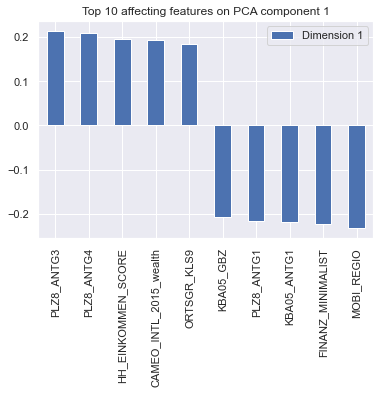

```python
pca_top_features(azdias_cleaned_0Missing_scaled, pca_32_1, 1, 5)
```

```python
# Map weights for the second principal component to corresponding feature names
# and then print the linked values, sorted by weight.
pca_results(azdias_cleaned_0Missing_scaled, pca_32_1, 2)
```

|  | Explained Variance | ALTERSKATEGORIE_GROB | SEMIO_ERL | FINANZ_VORSORGER | SEMIO_LUST | RETOURTYP_BK_S | FINANZ_HAUSBAUER | SEMIO_KRIT | W_KEIT_KIND_HH | PLZ8_ANTG3 | ... | ONLINE_AFFINITAET | SEMIO_FAM | FINANZ_ANLEGER | SEMIO_KULT | FINANZ_UNAUFFAELLIGER | FINANZ_SPARER | SEMIO_TRADV | SEMIO_PFLICHT | PRAEGENDE_JUGENDJAHRE_decade | SEMIO_REL |
| --- | --- | --- | --- | --- | --- | --- | --- | --- | --- | --- | --- | --- | --- | --- | --- | --- | --- | --- | --- | --- | --- |
| Dimension 2 | 0.137088 | 0.2454 | 0.2243 | 0.214 | 0.1693 | 0.1612 | 0.1306 | 0.1219 | 0.1199 | 0.1174 | ... | -0.1628 | -0.1722 | -0.1937 | -0.2121 | -0.217 | -0.2177 | -0.2186 | -0.2253 | -0.237 | -0.2516 |

1 rows × 65 columns

```
The Explained Variance for component 2 is 13.71% and the graph below shows the 10 features affecting this component the most
```

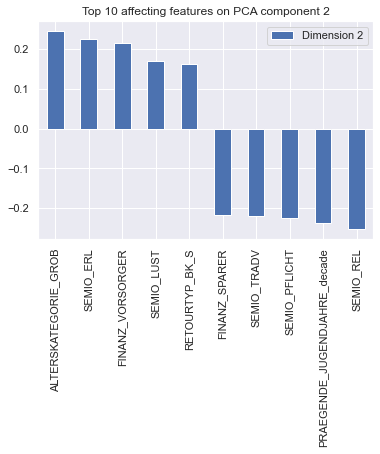

```python
pca_top_features(azdias_cleaned_0Missing_scaled, pca_32_1, 2, 5)
```

```python
# Map weights for the third principal component to corresponding feature names
# and then print the linked values, sorted by weight.
pca_results(azdias_cleaned_0Missing_scaled, pca_32_1, 3)
```

|  | Explained Variance | SEMIO_VERT | SEMIO_SOZ | SEMIO_FAM | SEMIO_KULT | FINANZ_MINIMALIST | RETOURTYP_BK_S | FINANZ_VORSORGER | W_KEIT_KIND_HH | ALTERSKATEGORIE_GROB | ... | FINANZ_UNAUFFAELLIGER | FINANZ_SPARER | PRAEGENDE_JUGENDJAHRE_decade | SEMIO_ERL | FINANZ_ANLEGER | SEMIO_RAT | SEMIO_KRIT | SEMIO_DOM | SEMIO_KAEM | ANREDE_KZ |
| --- | --- | --- | --- | --- | --- | --- | --- | --- | --- | --- | --- | --- | --- | --- | --- | --- | --- | --- | --- | --- | --- |
| Dimension 3 | 0.096442 | 0.3481 | 0.2637 | 0.2515 | 0.2316 | 0.1567 | 0.1159 | 0.0981 | 0.0947 | 0.0822 | ... | -0.0926 | -0.1012 | -0.1075 | -0.1699 | -0.1881 | -0.219 | -0.2691 | -0.3128 | -0.3372 | -0.3677 |

1 rows × 65 columns

```
The Explained Variance for component 3 is 9.64% and the graph below shows the 10 features affecting this component the most
```

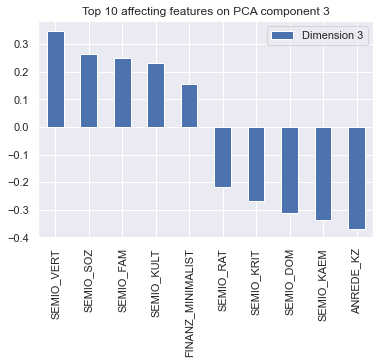

```python
pca_top_features(azdias_cleaned_0Missing_scaled, pca_32_1, 3, 5)
```

```python
pca_results(azdias_cleaned_filledNaN_scaled, pca_32_2, 1)
```

|  | Explained Variance | PLZ8_ANTG3 | EWDICHTE | ORTSGR_KLS9 | FINANZ_SPARER | PLZ8_ANTG4 | CAMEO_INTL_2015_wealth | PLZ8_ANTG2 | HH_EINKOMMEN_SCORE | ARBEIT | ... | FINANZ_VORSORGER | ALTERSKATEGORIE_GROB | INNENSTADT | PLZ8_GBZ | KONSUMNAEHE | KBA05_GBZ | KBA05_ANTG1 | PLZ8_ANTG1 | MOBI_REGIO | FINANZ_MINIMALIST |
| --- | --- | --- | --- | --- | --- | --- | --- | --- | --- | --- | --- | --- | --- | --- | --- | --- | --- | --- | --- | --- | --- |
| Dimension 1 | 0.159356 | 0.2229 | 0.1957 | 0.1856 | 0.1807 | 0.1806 | 0.168 | 0.1525 | 0.1505 | 0.1469 | ... | -0.1424 | -0.1475 | -0.1526 | -0.1628 | -0.1718 | -0.21 | -0.2158 | -0.2209 | -0.2239 | -0.229 |

1 rows × 65 columns

```
The Explained Variance for component 1 is 15.94% and the graph below shows the 10 features affecting this component the most
```

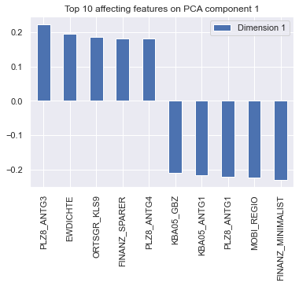

```python
pca_top_features(azdias_cleaned_filledNaN_scaled, pca_32_2, 1, 5)
```

```python
pca_results(azdias_cleaned_filledNaN_scaled, pca_32_2, 2)
```

|  | Explained Variance | ALTERSKATEGORIE_GROB | FINANZ_VORSORGER | SEMIO_ERL | SEMIO_LUST | RETOURTYP_BK_S | PLZ8_ANTG4 | FINANZ_HAUSBAUER | ORTSGR_KLS9 | CAMEO_INTL_2015_wealth | ... | ONLINE_AFFINITAET | SEMIO_KULT | SEMIO_RAT | SEMIO_TRADV | FINANZ_ANLEGER | SEMIO_PFLICHT | FINANZ_SPARER | FINANZ_UNAUFFAELLIGER | SEMIO_REL | PRAEGENDE_JUGENDJAHRE_decade |
| --- | --- | --- | --- | --- | --- | --- | --- | --- | --- | --- | --- | --- | --- | --- | --- | --- | --- | --- | --- | --- | --- |
| Dimension 2 | 0.127249 | 0.2461 | 0.2255 | 0.2113 | 0.1675 | 0.167 | 0.1427 | 0.1411 | 0.1291 | 0.1279 | ... | -0.1638 | -0.1723 | -0.1741 | -0.2123 | -0.218 | -0.222 | -0.2292 | -0.2294 | -0.2361 | -0.2406 |

1 rows × 65 columns

```
The Explained Variance for component 2 is 12.72% and the graph below shows the 10 features affecting this component the most
```

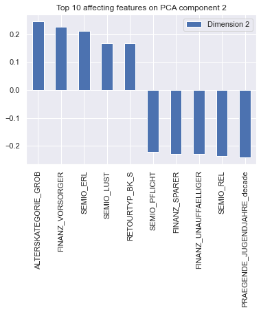

```python
pca_top_features(azdias_cleaned_filledNaN_scaled, pca_32_2, 2, 5)
```

```python
pca_results(azdias_cleaned_filledNaN_scaled, pca_32_2, 3)
```

|  | Explained Variance | SEMIO_VERT | SEMIO_SOZ | SEMIO_KULT | SEMIO_FAM | PLZ8_ANTG4 | FINANZ_MINIMALIST | CAMEO_INTL_2015_wealth | SEMIO_MAT | RETOURTYP_BK_S | ... | BALLRAUM | FINANZ_UNAUFFAELLIGER | KBA13_ANZAHL_PKW | SEMIO_RAT | FINANZ_ANLEGER | SEMIO_ERL | SEMIO_KRIT | SEMIO_DOM | ANREDE_KZ | SEMIO_KAEM |
| --- | --- | --- | --- | --- | --- | --- | --- | --- | --- | --- | --- | --- | --- | --- | --- | --- | --- | --- | --- | --- | --- |
| Dimension 3 | 0.094736 | 0.3498 | 0.2991 | 0.2932 | 0.2279 | 0.0962 | 0.0929 | 0.0776 | 0.0775 | 0.0628 | ... | -0.0761 | -0.0941 | -0.1036 | -0.1462 | -0.1648 | -0.1815 | -0.3151 | -0.3213 | -0.3405 | -0.3493 |

1 rows × 65 columns

```
The Explained Variance for component 3 is 9.47% and the graph below shows the 10 features affecting this component the most
```

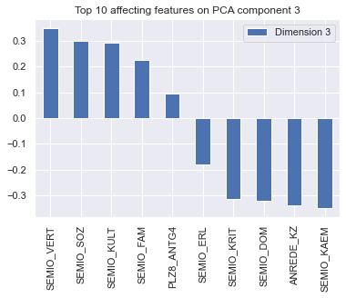

```python
pca_top_features(azdias_cleaned_filledNaN_scaled, pca_32_2, 3, 5)
```

### Discussion 2.3: Interpret Principal Components

- For the subdataset with **0 missing values** we see that:
  1. **First principal component** has the explained variance of **17.38%** and five positive features affecting it are "PLZ8_ANTG3", "PLZ8_ANTG4", "HH_EINKOMMEN_SCORE", "CAMEO_INTL_2015_wealth", and "ORTSGR_KLS9". Looking up these features in the Data_Dictionary.md, we can see they are related to the "more than six family houses in the PLZ8 region", "estimated household net income", "wealth", and "size of community". The top 5 negative affecting features are "KBA05_GBZ", "PLZ8_ANTG1", "KBA05_ANTG1", "FINANZ_MINIMALIST", and "MOBI_REGIO". These features are "number of buildings", "number of 1-2 family houses in the PLZ8 region", "number of 1-2 family houses", "low financial interest", and "movement patterns". They seem quite opposite for me and it is natural that they affect this component positively and negatively.
  2. **Second principal component** has the explained variance of **13.71%** and five positive features affecting it are "ALTERSKATEGORIE_GROB", "SEMIO_ERL", "FINANZ_VORSORGER", "SEMIO_LUST", "RETOURTYP_BK_S". They are "estimated age based on given name analysis", "event-oriented personality typology", "be prepared financial typology", "sensual-minded personality typology" and "return type". Top five negative affecting features "FINANZ_SPARER", "SEMIO_TRADV", "SEMIO_PFLICHT", "PRAEGENDE_JUGENDJAHRE_decade", and "SEMIO_REL". They are "money-saver financial typology", "traditional-minded, dutiful, religious personality typologies", and "decade of the person's youth". Also here they seem meaningful to me. Especially the personality typologies where dutiful religious traditional minded types are all together.
  3. **Third principal component** has the explained variance of **9.64%%** and five positive features affecting it are "SEMIO_VERT", "SEMIO_SOZ", "SEMIO_FAM", "SEMIO_KULT", and "FINANZ_MINIMALIST". They are "dreamful, socially-minded, family-minded, cultural-minded personality typologies" and "low financial interest financial typology". The top five features affecting negatively are "SEMIO_RAT", "SEMIO_KRIT", "SEMIO_DOM", "SEMIO_KAEM", and "ANREDE_KZ". They are "rational, critical-minded, dominant-minded, combative attitude personality typologies" and "gender". Also in the meaning they are opposite to the previous five ones and it makes sense to me.
- For the subdataset with **filled NaN values** we see that:
  1. **First principal component** has the explained variance of **15.94%** and five positive features affecting it are "PLZ8_ANTG3", "EWDICHTE", "ORTSGR_KLS9", "FINANZ_SPARER", and "PLZ8_ANTG4". They are "number of 6-10 family houses in the PLZ8 region", "density of households per square kilometer", "size of community", "money-saver financial typology", and "number of 10+ family houses in the PLZ8 region". Top five negatively affecting features on this component are "KBA05_GBZ", "KBA05_ANTG1", "PLZ8_ANTG1", "MOBI_REGIO", and "FINANZ_MINIMALIST". They are "number of buildings in the microcell", "number of 1-2 family houses in the microcell and in the PLZ8 region", "movement patterns", and "low financial interest financial typology", respectivly.
  2. **Second principal component** has the explained variance of **12.72%** and five positive features affecting it are "ALTERSKATEGORIE_GROB", "FINANZ_VORSORGER", "SEMIO_ERL", "SEMIO_LUST", "RETOURTYP_BK_S" which are "estimated age based on given name analysis", "be prepared financial typology", "event-oriented" and "sensual-minded personality typologies", and "return type". On the other hand, top five features negatively affecting this component are "SEMIO_PFLICHT", "FINANZ_SPARER", "FINANZ_UNAUFFAELLIGER", "SEMIO_REL", and "PRAEGENDE_JUGENDJAHRE_decade". Their meanings are "dutiful personality typology", "money-saver" and "inconspicuous financial typology", "religious personality typology", and "decade of the dominating movement of person's youth".
  3. **Third principal component** has the explained variance of **9.47%** and five positive features affecting it are "SEMIO_VERT", "SEMIO_SOZ", "SEMIO_KULT", "SEMIO_FAM", and "PLZ8_ANTG4". They mean "dreamful", "socially-minded", "cultural-minded", "family-minded personality typologies", and "number of 10+ family houses in the PLZ8 region". Top five negative affecting features are "SEMIO_ERL", "SEMIO_KRIT", "SEMIO_DOM", "ANREDE_KZ", and "SEMIO_KAEM". One is "gender" and the other four are "event-oriented, critical-minded, dominant-minded and combative attitude personality typologies".

## Step 3: Clustering

### Step 3.1: Apply Clustering to General Population

You've assessed and cleaned the demographics data, then scaled and transformed them. Now, it's time to see how the data clusters in the principal components space. In this substep, you will apply k-means clustering to the dataset and use the average within-cluster distances from each point to their assigned cluster's centroid to decide on a number of clusters to keep.

- Use sklearn's KMeans class to perform k-means clustering on the PCA-transformed data.
- Then, compute the average difference from each point to its assigned cluster's center. **Hint**: The KMeans object's `.score()` method might be useful here, but note that in sklearn, scores tend to be defined so that larger is better. Try applying it to a small, toy dataset, or use an internet search to help your understanding.
- Perform the above two steps for a number of different cluster counts. You can then see how the average distance decreases with an increasing number of clusters. However, each additional cluster provides a smaller net benefit. Use this fact to select a final number of clusters in which to group the data. **Warning**: because of the large size of the dataset, it can take a long time for the algorithm to resolve. The more clusters to fit, the longer the algorithm will take. You should test for cluster counts through at least 10 clusters to get the full picture, but you shouldn't need to test for a number of clusters above about 30.
- Once you've selected a final number of clusters to use, re-fit a KMeans instance to perform the clustering operation. Make sure that you also obtain the cluster assignments for the general demographics data, since you'll be using them in the final Step 3.3.

```python
from sklearn.cluster import KMeans
import time

azdias_cleaned_0Missing_pca = pca_32_1.fit_transform(azdias_cleaned_0Missing_scaled)
score = []

# Over a number of different cluster counts...
for i in range(1, 21):
    # run k-means clustering on the data and...
    start_time = time.time()
    kmeans = KMeans(n_clusters=i).fit(azdias_cleaned_0Missing_pca)
    duration_time = time.time() - start_time
    # compute the average within-cluster distances.
    tart_time = time.time()
    score.append(np.abs(kmeans.score(azdias_cleaned_0Missing_pca)))
    duration_time2 = time.time() - start_time

    print(f"The clustering with {i} clusters is done and the score is {score[-1]}. It took {duration_time:.2f} \
seconds to fit the data and {duration_time2:.2f} seconds to calculate the score.")
```

```
The clustering with 1 clusters is done and the score is 35859314.9612164. It took 1.83 seconds to fit the data and 2.08 seconds to calculate the score.
The clustering with 2 clusters is done and the score is 30693820.433069583. It took 4.57 seconds to fit the data and 4.80 seconds to calculate the score.
The clustering with 3 clusters is done and the score is 27864363.39158792. It took 6.11 seconds to fit the data and 6.34 seconds to calculate the score.
The clustering with 4 clusters is done and the score is 26221691.59641757. It took 7.88 seconds to fit the data and 8.11 seconds to calculate the score.
The clustering with 5 clusters is done and the score is 25025398.741487768. It took 8.22 seconds to fit the data and 8.46 seconds to calculate the score.
The clustering with 6 clusters is done and the score is 24026859.454615016. It took 9.25 seconds to fit the data and 9.47 seconds to calculate the score.
The clustering with 7 clusters is done and the score is 23136581.726138916. It took 12.53 seconds to fit the data and 12.77 seconds to calculate the score.
The clustering with 8 clusters is done and the score is 22442570.27843161. It took 12.18 seconds to fit the data and 12.41 seconds to calculate the score.
The clustering with 9 clusters is done and the score is 21967344.75800013. It took 17.72 seconds to fit the data and 17.98 seconds to calculate the score.
The clustering with 10 clusters is done and the score is 21374446.7833906. It took 17.43 seconds to fit the data and 17.66 seconds to calculate the score.
The clustering with 11 clusters is done and the score is 21167506.54956525. It took 20.04 seconds to fit the data and 20.28 seconds to calculate the score.
The clustering with 12 clusters is done and the score is 20582866.756478004. It took 24.19 seconds to fit the data and 24.43 seconds to calculate the score.
The clustering with 13 clusters is done and the score is 20291688.243101623. It took 26.53 seconds to fit the data and 26.77 seconds to calculate the score.
The clustering with 14 clusters is done and the score is 20074160.69750562. It took 27.06 seconds to fit the data and 27.31 seconds to calculate the score.
The clustering with 15 clusters is done and the score is 19568169.443445828. It took 31.60 seconds to fit the data and 31.85 seconds to calculate the score.
The clustering with 16 clusters is done and the score is 19636128.541109327. It took 33.47 seconds to fit the data and 33.73 seconds to calculate the score.
The clustering with 17 clusters is done and the score is 19241673.85333333. It took 33.08 seconds to fit the data and 33.33 seconds to calculate the score.
The clustering with 18 clusters is done and the score is 18979319.45059909. It took 38.08 seconds to fit the data and 38.37 seconds to calculate the score.
The clustering with 19 clusters is done and the score is 18689698.270361643. It took 39.66 seconds to fit the data and 39.90 seconds to calculate the score.
The clustering with 20 clusters is done and the score is 18608861.06992255. It took 37.63 seconds to fit the data and 37.88 seconds to calculate the score.
```

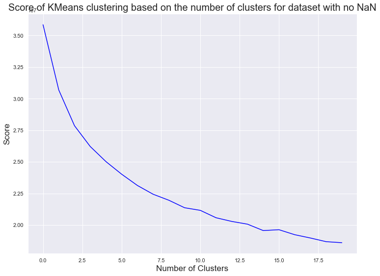

```python
# Investigate the change in within-cluster distance across number of clusters.
# HINT: Use matplotlib's plot function to visualize this relationship.
fig, ax = plt.subplots(figsize=(12, 9))

ax.plot(score, color='blue');
ax.xaxis.set_tick_params(width=0)
ax.set_ylabel("Score", fontsize=17);
ax.set_xlabel("Number of Clusters", fontsize=17)
ax.set_title("Score of KMeans clustering based on the number of clusters for dataset with no NaN", fontsize=20);
```